# Assignment 3

Mohammad Shehab

### Introduction

This assignment is developed using `R` language and the RStudio IDE. This project uses `tidyverse`

### Dependency:

- xquartz viewer
- [tidyverse](https://www.tidyverse.org/) library
- [brew](https://brew.sh/) Package manager for Mac

### Getting Started

```r
library("tidyverse")
```

Assignment Description: This Assignment involves the following questions from Chapter 7: Tibbles with tibble and chapter 9: Tidy Data with tidyr:

Before we start answering the questions we load some data for testing

```r
library(datasets)
  data(cars)
    summary(cars)
```

```
##      speed           dist
##  Min.   : 4.0   Min.   :  2.00
##  1st Qu.:12.0   1st Qu.: 26.00
##  Median :15.0   Median : 36.00
##  Mean   :15.4   Mean   : 42.98
##  3rd Qu.:19.0   3rd Qu.: 56.00
##  Max.   :25.0   Max.   :120.00
```

### Part I

**Q** : 1 - What does `tibble::enframe()` do? When might you use it?

**A** : Works like a dictionary the `tibble::enframe()` function converts named vectors to a data frame with keys and values for example:

```r
enframe(c(a = 1, b = 2, c = 3))
```

```
## # A tibble: 3 x 2
##   name  value
##   <chr> <dbl>
## 1 a         1
## 2 b         2
## 3 c         3
```

**Q** : 2 - What option controls how many additional column names are printed at the footer of a tibble

**A**: The help page for the `print()` method of tibble objects is discussed in `?print.tbl`. The `n_extra` argument determines the number of extra columns to print information for.

```r
?(print.tbl)
```

### Part II

##### Working with Tidy Data with tidyr

**Q** 3 - Compute the `rate` for `table2`, and `table4a` + `table4b`. You will need to perform four operations:

1. Extract the number of TB cases per country per year.
2. Extract the matching population per country per year.
3. Divide cases by population, and multiply by 10000.
4. Store back in the appropriate place.

Which representation is easiest to work with? Which is hardest? Why?

**A**

To calculate cases per person, we need to divide cases by population for each country and year. This is easiest if the cases and population variables are two columns in a data frame in which rows represent (country, year) combinations.

```r
## create separate tables for cases
## and population and ensure that they are sorted in the same order

t2_cases <- filter(table2, type == "cases") %>%
  rename(cases = count) %>%
    arrange(country, year)

# Display The Cases
t2_cases;
```

```
## # A tibble: 6 x 4
##   country      year type   cases
##   <chr>       <int> <chr>  <int>
## 1 Afghanistan  1999 cases    745
## 2 Afghanistan  2000 cases   2666
## 3 Brazil       1999 cases  37737
## 4 Brazil       2000 cases  80488
## 5 China        1999 cases 212258
## 6 China        2000 cases 213766
```

```r
t2_population <- filter(table2, type == "population") %>%
  rename(population = count) %>%
    arrange(country, year)

# Display t2 populations
t2_population;
```

```
## # A tibble: 6 x 4
##   country      year type       population
##   <chr>       <int> <chr>           <int>
## 1 Afghanistan  1999 population   19987071
## 2 Afghanistan  2000 population   20595360
## 3 Brazil       1999 population  172006362
## 4 Brazil       2000 population  174504898
## 5 China        1999 population 1272915272
## 6 China        2000 population 1280428583
```

```r
## Create the population and cases columns, and calculate the cases per capita in a new column.[^ex-12.2.2]

t2_cases_per_cap <- tibble(year = t2_cases$year,
  country = t2_cases$country,
  cases = t2_cases$cases,
  population = t2_population$population) %>%
    mutate(cases_per_cap = (cases / population) * 10000) %>%
      select(country, year, cases_per_cap)

## Display type 2 cases per capita
t2_cases_per_cap
```

```
## # A tibble: 6 x 3
##   country      year cases_per_cap
##   <chr>       <int>         <dbl>
## 1 Afghanistan  1999         0.373
## 2 Afghanistan  2000         1.29
## 3 Brazil       1999         2.19
## 4 Brazil       2000         4.61
## 5 China        1999         1.67
## 6 China        2000         1.67
```

```r
## To store this new variable in the appropriate location, we will add new rows to `table2`.

t2_cases_per_cap <- t2_cases_per_cap %>%
  mutate(type = "cases_per_cap") %>%
  rename(count = cases_per_cap)
```

```r
bind_rows(table2, t2_cases_per_cap) %>%
  arrange(country, year, type, count)
```

```
## # A tibble: 18 x 4
##    country      year type            count
##    <chr>       <int> <chr>           <dbl>
##  1 Afghanistan  1999 cases         7.45e+2
##  2 Afghanistan  1999 cases_per_cap 3.73e-1
##  3 Afghanistan  1999 population    2.00e+7
##  4 Afghanistan  2000 cases         2.67e+3
##  5 Afghanistan  2000 cases_per_cap 1.29e+0
##  6 Afghanistan  2000 population    2.06e+7
##  7 Brazil       1999 cases         3.77e+4
##  8 Brazil       1999 cases_per_cap 2.19e+0
##  9 Brazil       1999 population    1.72e+8
## 10 Brazil       2000 cases         8.05e+4
## 11 Brazil       2000 cases_per_cap 4.61e+0
## 12 Brazil       2000 population    1.75e+8
## 13 China        1999 cases         2.12e+5
## 14 China        1999 cases_per_cap 1.67e+0
## 15 China        1999 population    1.27e+9
## 16 China        2000 cases         2.14e+5
## 17 China        2000 cases_per_cap 1.67e+0
## 18 China        2000 population    1.28e+9
```

Note that after adding the `cases_per_cap` rows, the type of `count` is coerced to `numeric` (double) because `cases_per_cap` is not an integer.

```r
## For `table4a` and `table4b`, create a new table for cases per capita which ## we'll name `table4c`, with country rows and year columns.

table4c <-
  tibble(
    country = table4a$country,
    `1999` = table4a[["1999"]] / table4b[["1999"]] * 10000,
    `2000` = table4a[["2000"]] / table4b[["2000"]] * 10000
  )
table4c
```

```
## # A tibble: 3 x 3
##   country     `1999` `2000`
##   <chr>        <dbl>  <dbl>
## 1 Afghanistan  0.373   1.29
## 2 Brazil       2.19    4.61
## 3 China        1.67    1.67
```

**Analysis**

Neither table is particularly easy to work with. Since `table2` has separate rows for cases and population we needed to generate a table with columns for cases and population where we could calculate cases per capita. `table4a` and `table4b` split the cases and population variables into different tables which made it easy to divide cases by population. However, we had to repeat this calculation for each row.

The ideal format of a data frame to answer this question is one with columns `country`, `year`, `cases`, and `population`. Then problem could be answered with a single `mutate()` call.

## Part III

**Q** 4 - Recreate the plot showing change in cases over time using `table2 instead of`table1`. What do you need to do first ?

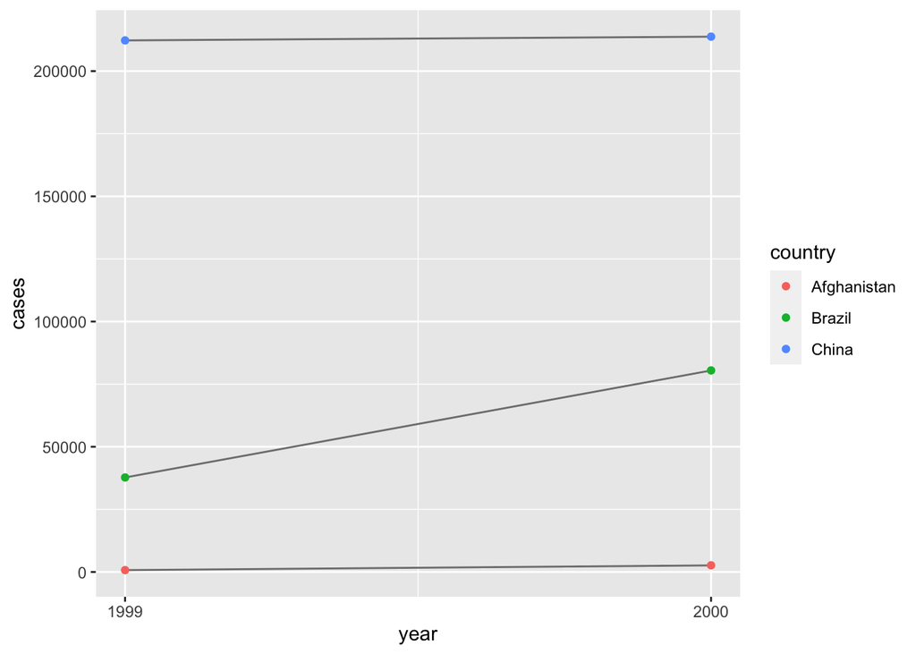

```r
table2 %>%
  filter(type == "cases") %>%
    ggplot(aes(year, count)) +
      geom_line(aes(group = country), colour = "grey50") +
        geom_point(aes(colour = country)) +
          scale_x_continuous(breaks = unique(table2$year)) +
  ylab("cases")
```

## Part IV

**Q** 5 - Tidy the simple tibble below. Do you need to make it wider or longer? What are the variables?

```r
preg <- tribble(
  ~pregnant, ~male, ~female,
  "yes", NA, 10,
  "no", 20, 12
)
```

To tidy the `preg` tibble, we need to use `gather()`. The variables in this data are:

- `sex` (“female”, “male”)
- `pregnant` (“yes”, “no”)
- `count`, which is a non-negative integer representing the number of observations.

The observations in this data are unique combinations of sex and pregnancy status.

```r
preg_tidy <- preg %>%
  gather(male, female, key = "sex", value = "count")
preg_tidy
```

```
## # A tibble: 4 x 3
##   pregnant sex    count
##   <chr>    <chr>  <dbl>
## 1 yes      male      NA
## 2 no       male      20
## 3 yes      female    10
## 4 no       female    12
```

We can simplify the tidied data frame by removing the (male, pregnant) row with the missing value of `NA`.

```r
preg_tidy2 <- preg %>%
  gather(male, female, key = "sex", value = "count", na.rm = TRUE)
preg_tidy2
```

```
## # A tibble: 3 x 3
##   pregnant sex    count
##   <chr>    <chr>  <dbl>
## 1 no       male      20
## 2 yes      female    10
## 3 no       female    12
```

Although we have already done enough to make the data tidy, there’s some other changes that can be made to clean this data. If a variable takes two values, like `pregnant` and `sex`, it is often preferable to store them as logical vectors.

```r
preg_tidy3 <- preg_tidy2 %>%
  mutate(
    female = sex == "female",
    pregnant = pregnant == "yes"
  ) %>%
  select(female, pregnant, count)
preg_tidy3
```

```
## # A tibble: 3 x 3
##   female pregnant count
##   <lgl>  <lgl>    <dbl>
## 1 FALSE  FALSE       20
## 2 TRUE   TRUE        10
## 3 TRUE   FALSE       12
```

In the previous data frame, we named the logical variable representing the sex `female`, not `sex`.

This makes the meaning of the variable self-documenting. If the variable were named `sex` with values `TRUE` and `FALSE`, without reading the documentation, we wouldn’t know whether `TRUE` means male or female.

Finally compare the `filter()` calls to select non-pregnant females from `preg_tidy2` and `preg_tidy`.

```r
filter(preg_tidy2, sex == "female", pregnant == "no")
```

```
## # A tibble: 1 x 3
##   pregnant sex    count
##   <chr>    <chr>  <dbl>
## 1 no       female    12
```

```r
filter(preg_tidy3, female, !pregnant)
```

```
## # A tibble: 1 x 3
##   female pregnant count
##   <lgl>  <lgl>    <dbl>
## 1 TRUE   FALSE       12
```